# Inpatient Capacity in the U.S. During the 2020 COVID-19 Crisis

# Methods: Data Transformations

### Create Transformed Data Cuts for Visualizations

Collapse to Entire U.S.

```r
# Use this to see nationwide change over time
beds_main_total <- beds_main %>%
  group_by(collection_date) %>% # Summing by date essentially removes the state variable to get daily totals for the entire country
  summarise(inpatient.occupied = sum(inpatient.occupied, na.rm = TRUE),
            covid.occupied = sum(covid.occupied, na.rm = TRUE),
            icu.occupied = sum(icu.occupied, na.rm = TRUE),
            inpatient.capacity = sum(inpatient.capacity, na.rm = TRUE),
            icu.capacity = sum(icu.capacity, na.rm = TRUE))
```

# Methods: Data Transformations

### Create Transformed Data Cuts for Visualizations

Matrices for heatmaps: States as columns, days as rows

```r
# Inpatient Percent of Capacity
inpat.percent <- spread(beds_main[,c(1:2,4)],state,inpatient.percent) # spread() function reshapes data
inpat.percent.mat <- as.matrix(inpat.percent[,2:50]) # turn into matrix for heatmap
rnames <- as.character(inpat.percent[,1]) # Use dates as row names in matrix
rownames(inpat.percent.mat) <- rnames

tail(inpat.percent.mat) # Used 'tail()' rather than 'head()' because many early values are missing
```

```
##                   AL        AR        AZ        CA        CO        CT
## 2020-07-09 0.7538197 0.5630524 0.8414023 0.6455666 0.4960630 0.6959100
## 2020-07-10 0.7321362 0.5572424 0.7481797 0.6625192 0.5123746 0.7011340
## 2020-07-11 0.7033995 0.5222136 0.7930467 0.6535288 0.5581802 0.6790002
## 2020-07-12 0.6789343 0.5168311 0.7375992 0.6311033 0.4464441 0.6526213
## 2020-07-13 0.6999812 0.5091053 0.7576035 0.6267920 0.4800550 0.6551640
## 2020-07-14 0.7680185 0.6376269 0.7700521 0.6656410 0.5325779 0.7077473
##                   DC        DE        FL        GA        IA        ID
## 2020-07-09 0.7371408 0.6947368 0.8057975 0.7405040 0.5394343 0.4627329
## 2020-07-10 0.7469837 0.6824903 0.8044438 0.7347456 0.5336587 0.4481409
## 2020-07-11 0.7260808 0.6607670 0.7425622 0.7319153 0.5116591 0.4464494
## 2020-07-12 0.7101604 0.6541257 0.7284686 0.7045373 0.4653533 0.4441176
## 2020-07-13 0.7041801 0.6692944 0.7696943 0.7324728 0.4899340 0.4718714
## 2020-07-14 0.4929245 0.6887125 0.7883550 0.7479587 0.4986180 0.6261567
##                   IL        IN        KS        KY        LA        MA
## 2020-07-09 0.6056539 0.6098482 0.5291940 0.6814775 0.6341410 0.7935026
## 2020-07-10 0.6048439 0.5865450 0.5239598 0.6201878 0.6462791 0.7766038
## 2020-07-11 0.5812562 0.5432845 0.4906022 0.5960227 0.6353172 0.7957160
## 2020-07-12 0.5455396 0.5568934 0.4633722 0.5702964 0.5972393 0.7817239
## 2020-07-13 0.5512380 0.5472308 0.4779589 0.5162541 0.6291766 0.7801894
## 2020-07-14 0.5922217 0.6101551 0.5002966 0.5969697 0.6569880 0.7868409
##                   MD        ME        MI        MN        MO        MS
## 2020-07-09 0.7391304 0.6255629 0.6996576 0.6308554 0.5920500 0.6483680
## 2020-07-10 0.7653509 0.6363958 0.6832911 0.6173079 0.5871401 0.6389311
## 2020-07-11 0.7521739 0.6427070 0.6569369 0.5910761 0.5550427 0.5669211
## 2020-07-12 0.6941432 0.6400326 0.6344453 0.5650808 0.5440715 0.6043636
## 2020-07-13 0.6826087 0.6458978 0.6471756 0.5826511 0.5570743 0.5973342
## 2020-07-14 0.7615063 0.7091274 0.7014155 0.6061936 0.6228377 0.6335840
##                   MT        NC        ND        NE        NH        NJ
## 2020-07-09 0.5121714 0.7134752 0.4763889 0.6365209 0.6554085 0.6445312
## 2020-07-10 0.5169661 0.7012337 0.4720000 0.6257485 0.6440247 0.7249933
## 2020-07-11 0.5746141 0.6781630 0.4821429 0.5990148 0.6266502 0.6886001
## 2020-07-12 0.5113438 0.6737828 0.4301994 0.5941645 0.5909277 0.6597417
## 2020-07-13 0.5189355 0.6954770 0.4446003 0.6011271 0.5900968 0.6944785
## 2020-07-14 0.5497512 0.6638603 0.4462810 0.6260399 0.7046714 0.6998200
##                   NM        NV        NY        OH        OK        OR
## 2020-07-09 0.6839536 0.8091473 0.6954588 0.6002139 0.4771523 0.6670644
## 2020-07-10 0.6940789 0.8082972 0.6967143 0.5798453 0.4581911 0.6817403
## 2020-07-11 0.6450641 0.8049703 0.6818420 0.5650611 0.4090548 0.6437883
## 2020-07-12 0.5964912 0.8108557 0.6703718 0.5298570 0.4029800 0.6116838
```

[output cut: 8 more lines]

```
## 2020-07-14 0.6653673 0.8600683 0.7550463 0.3157895 0.6843561 0.7061854
##                   UT        VA        VT        WA        WI        WV
## 2020-07-09 0.5656824 0.5953578 0.6517857 0.6130573 0.5195746 0.7305535
## 2020-07-10 0.5644860 0.5725038 0.6409396 0.5992915 0.5045980 0.7207437
## 2020-07-11 0.5653524 0.5257751 0.6324786 0.5697724 0.4652726 0.6781431
## 2020-07-12 0.4870317 0.5170485 0.6178266 0.5550197 0.4641424 0.6561185
## 2020-07-13 0.5381176 0.5742199 0.6101896 0.5346715 0.4746245 0.6692885
## 2020-07-14 0.4878049 0.5917579 0.6540284 0.5545651 0.4632945 0.7282099
##                   WY
## 2020-07-09 0.5117994
## 2020-07-10 0.4604743
## 2020-07-11 0.4677419
## 2020-07-12 0.3702970
## 2020-07-13 0.3920792
## 2020-07-14 0.3396226
```

```r
# COVID Percent of Capacity
cov.percent <- spread(beds_main[,c(1:2,6)],state,covid.percent)
cov.percent.mat <- as.matrix(cov.percent[,2:50])
rnames <- as.character(cov.percent[,1])
rownames(cov.percent.mat) <- rnames

# ICU Percent of Capacity
ICU.percent <- spread(beds_main[,c(1:2,8)],state,icu.percent)
ICU.percent.mat <- as.matrix(ICU.percent[,2:50])
rnames <- as.character(ICU.percent[,1])
rownames(ICU.percent.mat) <- rnames
```

# Results: Visualizations

### Plot the variables in question for the entire U.S.

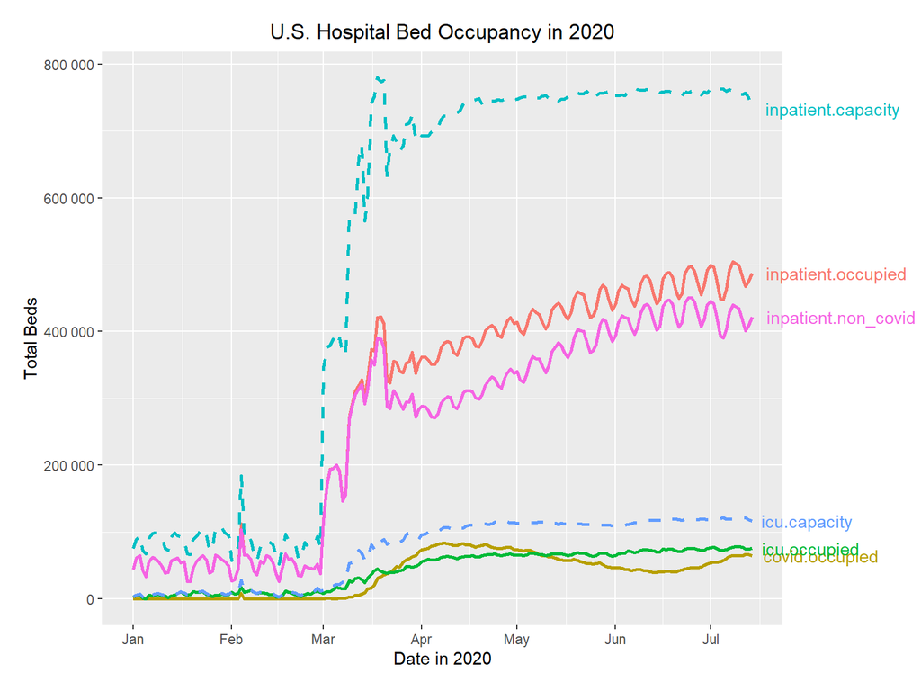

```r
# Add one more variable to show the total inpatients not including COVID-19
beds_main_total <- transform(beds_main_total, inpatient.non_covid = inpatient.occupied - covid.occupied)
# Reshape data using 'melt()' function to use for a ggplot2 graph
beds_main_total_melt <- reshape2::melt(beds_main_total, id.var='collection_date')

# Create line plot to show development over the course of the year
lp <- ggplot(beds_main_total_melt, aes(x = collection_date, y = value, col = variable)) + # Uses "melted" data to plot all variables at once
  geom_line(size = 1, aes(linetype = variable)) +
  scale_linetype_manual(values=c("solid", "solid", "solid", "dashed", "dashed", "solid")) + # Make capacities dashed
  labs(title = "U.S. Hospital Bed Occupancy in 2020", x = "Date in 2020", y = "Total Beds") +
  theme(plot.title = element_text(hjust = 0.5), legend.position = "none", plot.margin = unit(c(1,6,1,1), "lines")) +
  # Add axis and series labels
  scale_y_continuous(labels = number) +
  geom_text(data = subset(beds_main_total_melt, collection_date == 18457), aes(label = variable), hjust = -.1) +
  scale_colour_discrete(guide = 'none') +
  scale_x_date(date_labels = "%b", date_breaks = "1 month")

# Allow series labels to hang off the chart
gt <- ggplotGrob(lp)
gt$layout$clip[gt$layout$name == "panel"] <- "off"
grid.draw(gt)
```

# Results: Visualizations

### Heatmaps: Hospital Bed Occupancy by State

Could use line plots, but they get crowded with 50 series. Heatmaps help with this and can still show change over time

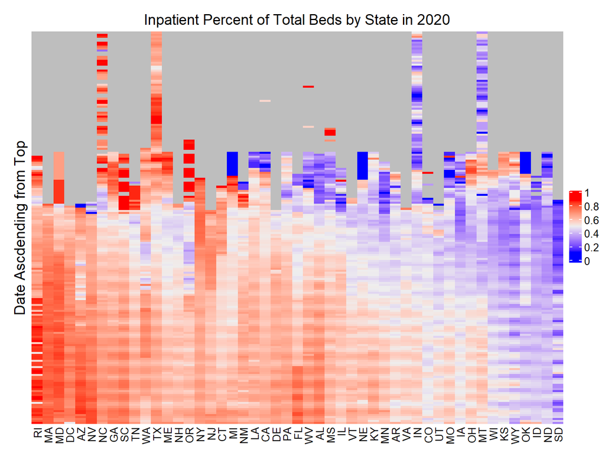

```r
# Inpatient Percent of Capacity
Heatmap(inpat.percent.mat,
        row_title = "Date Ascdending from Top",
        column_title = "Inpatient Percent of Total Beds by State in 2020",
        cluster_rows = FALSE, # Want rows to remain sorted by date
        show_row_names = FALSE,
        show_column_dend = FALSE,
        column_names_gp = gpar(fontsize = 10),
        heatmap_legend_param = list(title = "")
        )
```

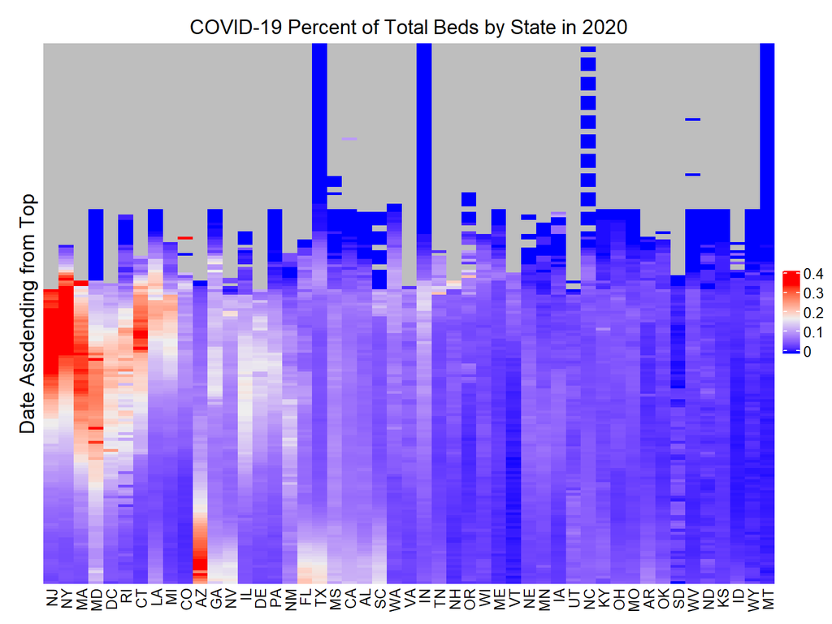

```r
# COVID Percent of Capacity
Heatmap(cov.percent.mat,
        row_title = "Date Ascdending from Top",
        column_title = "COVID-19 Percent of Total Beds by State in 2020",
        cluster_rows = FALSE,
        show_row_names = FALSE,
        show_column_dend = FALSE,
        column_names_gp = gpar(fontsize = 10),
        heatmap_legend_param = list(title = "")
        )
```

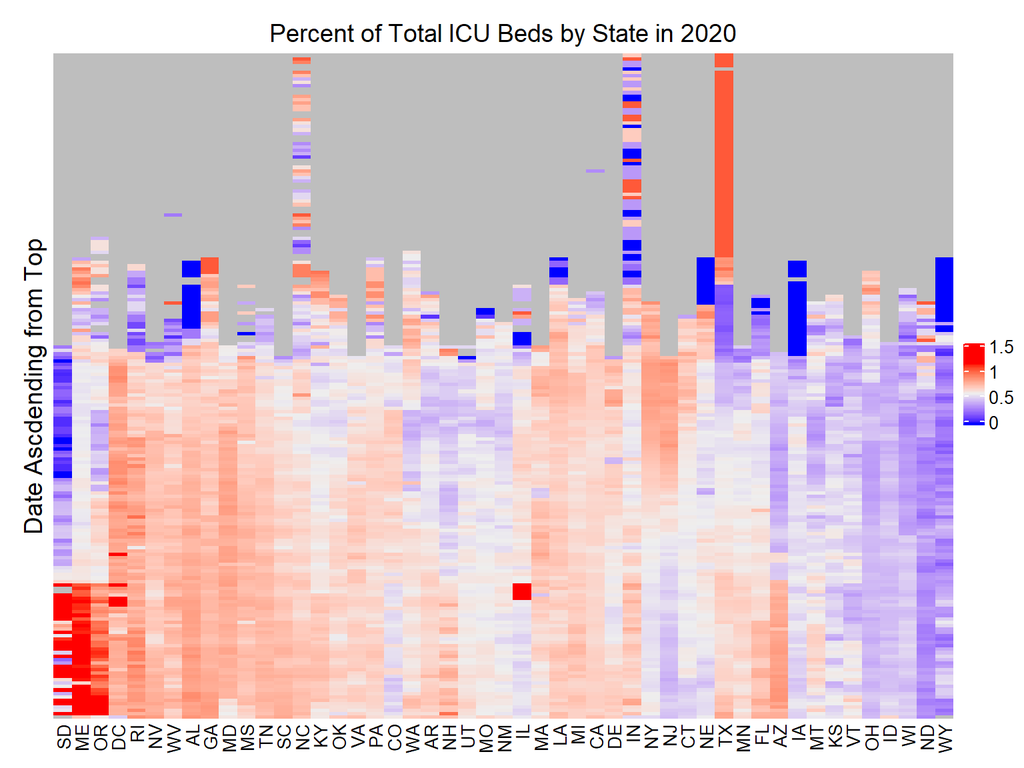

```r
# ICU Percent of Capacity
Heatmap(ICU.percent.mat,
        row_title = "Date Ascdending from Top",
        column_title = "Percent of Total ICU Beds by State in 2020",
        cluster_rows = FALSE,
        show_row_names = FALSE,
        show_column_dend = FALSE,
        column_names_gp = gpar(fontsize = 10),
        heatmap_legend_param = list(title = "")
        )
```

```r
# Column clustering allows us to approximate which states have been pushed closest to capacity
# Maps also show the initial "wave" of cases in some states. Reflects that states were initially pushed to their limits but then expanded capacity
# Interestingly, the states with the highest overall occupancy % did not necessarily have highest ICU occupancy
```

# Results: Visualizations

### Heatmaps with pre-COVID-19 Hospital Capacities

Redefine Inpatient capacity and ICU capacity to their initial values

```r
# Inpatient original cap
  # Using 'which()' and 'ave()' functions, find the inpatient capacity for each state at the earliest date available
  # in the data to estimate what capacity would have been before the invlux of COVID-19 cases
beds_main_inpat_nona <- beds_main[!is.na(beds_main$inpatient.capacity),]
original_cap <- beds_main_inpat_nona[
  which(beds_main_inpat_nona$collection_date ==
          ave(beds_main_inpat_nona$collection_date, beds_main_inpat_nona$state, FUN = min)), c(1, 9)]

# ICU original cap
beds_main_icu_nona <- beds_main[!is.na(beds_main$icu.capacity),]
original_cap_icu <- beds_main_icu_nona[
  which(beds_main_icu_nona$collection_date ==
          ave(beds_main_icu_nona$collection_date, beds_main_icu_nona$state, FUN = min)), c(1, 10)]

# Merge the inpatient and ICU initial capacities with 'left_join()' funciton
original_cap <- left_join(original_cap, original_cap_icu, by = "state")

original_cap <- rename(original_cap, "inpat.cap.orig" = inpatient.capacity)
original_cap <- rename(original_cap, "icu.cap.orig" = icu.capacity)

# Merge back onto main dataset
beds_main_origcap <- left_join(beds_main, original_cap, by = "state")
beds_main_origcap$icu.cap.orig <- ifelse(beds_main_origcap$icu.occupied == 0, NA, beds_main_origcap$icu.cap.orig)

# Redefine %s as portion of initial capacities rather than the dynamic capacities
beds_main_origcap$inpatient.percent <- beds_main_origcap$inpatient.occupied / beds_main_origcap$inpat.cap.orig
beds_main_origcap$covid.percent <- beds_main_origcap$covid.occupied / beds_main_origcap$inpat.cap.orig
beds_main_origcap$icu.percent <- beds_main_origcap$icu.occupied / beds_main_origcap$icu.cap.orig
```

Now remake Heatmap matrices

```r
# Inpatient Percent of Capacity
inpat.percent.orig <- spread(beds_main_origcap[,c(1:2,4)],state,inpatient.percent)
inpat.percent.orig.mat <- as.matrix(inpat.percent.orig[,2:50])
rnames <- as.character(inpat.percent.orig[,1])
rownames(inpat.percent.orig.mat) <- rnames

# COVID Percent of Capacity
cov.percent.orig <- spread(beds_main_origcap[,c(1:2,6)],state,covid.percent)
cov.percent.orig.mat <- as.matrix(cov.percent.orig[,2:50])
rnames <- as.character(cov.percent.orig[,1])
rownames(cov.percent.orig.mat) <- rnames

# ICU Percent of Capacity
ICU.percent.orig <- spread(beds_main_origcap[,c(1:2,8)],state,icu.percent)
ICU.percent.orig.mat <- as.matrix(ICU.percent.orig[,2:50])
rnames <- as.character(ICU.percent.orig[,1])
rownames(ICU.percent.orig.mat) <- rnames
```

And remake Heatmaps

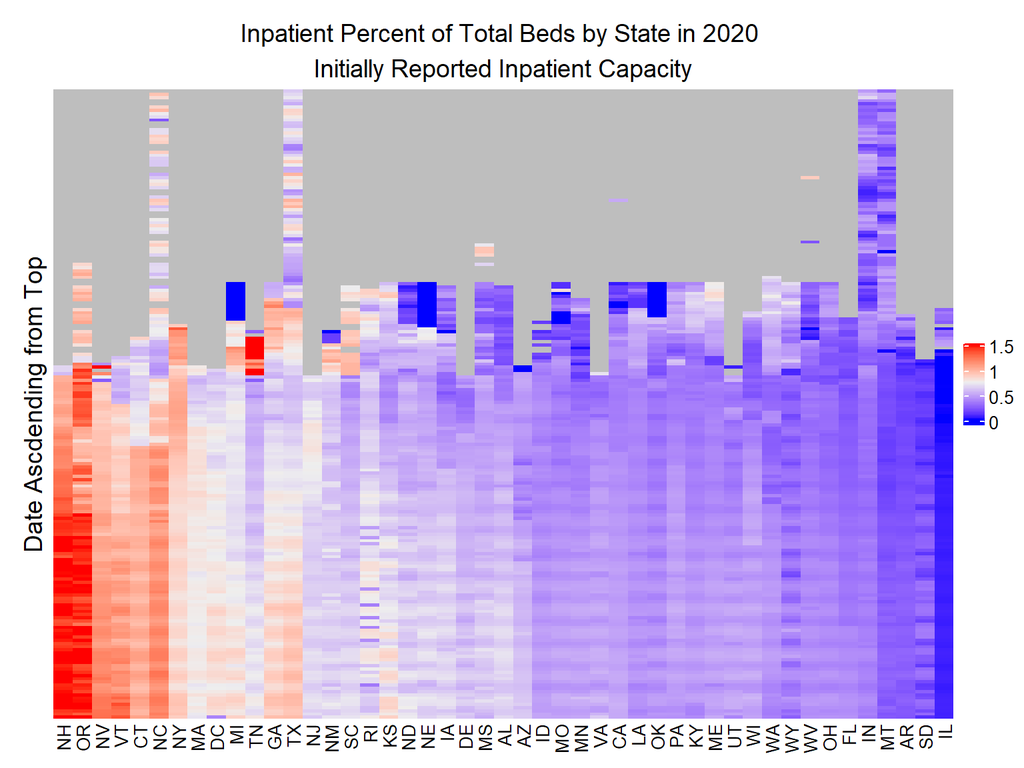

```r
# Inpatient Percent of Capacity
Heatmap(inpat.percent.orig.mat[,-c(5,19)], # Remove outliers Colorado and Maryland
        row_title = "Date Ascdending from Top",
        column_title = "Inpatient Percent of Total Beds by State in 2020 \nInitially Reported Inpatient Capacity",
        cluster_rows = FALSE,
        show_row_names = FALSE,
        show_column_dend = FALSE,
        column_names_gp = gpar(fontsize = 10),
        heatmap_legend_param = list(title = "")
        )
```

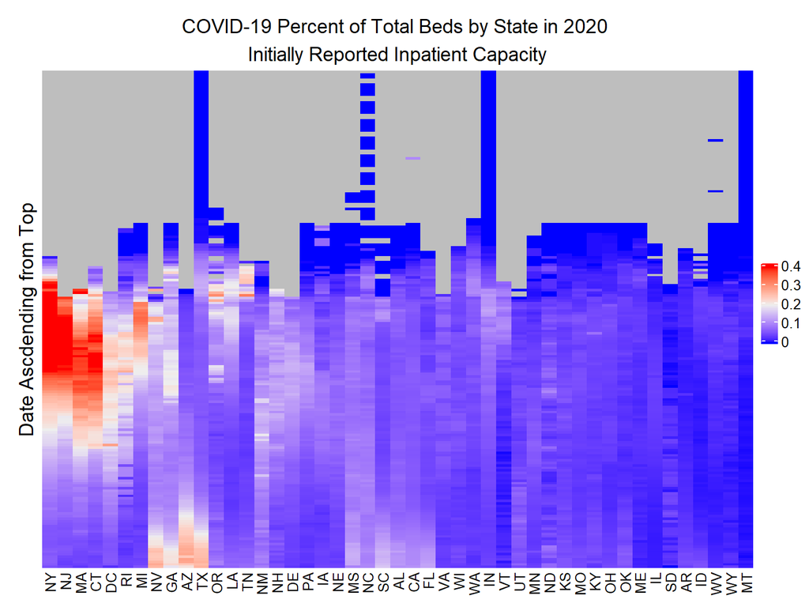

```r
# COVID Percent of Capacity
Heatmap(cov.percent.orig.mat[,-c(5,19)], # Remove outliers Colorado and Maryland
        row_title = "Date Ascdending from Top",
        column_title = "COVID-19 Percent of Total Beds by State in 2020 \nInitially Reported Inpatient Capacity",
        cluster_rows = FALSE,
        show_row_names = FALSE,
        show_column_dend = FALSE,
        column_names_gp = gpar(fontsize = 10),
        heatmap_legend_param = list(title = "")
        )
```

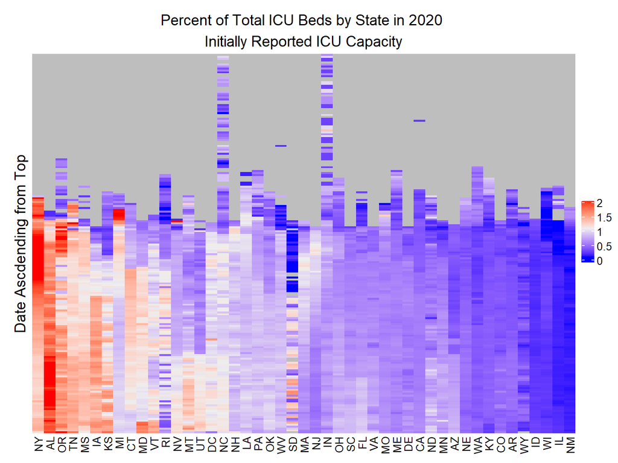

```r
# ICU Percent of Capacity
Heatmap(ICU.percent.orig.mat[,-c(10,42)], # Remove outliers Georgia and Texas
        row_title = "Date Ascdending from Top",
        column_title = "Percent of Total ICU Beds by State in 2020 \nInitially Reported ICU Capacity",
        cluster_rows = FALSE,
        show_row_names = FALSE,
        show_column_dend = FALSE,
        column_names_gp = gpar(fontsize = 10),
        heatmap_legend_param = list(title = "")
        )
```

```r
# Scale drastically increased
# Shows which states had to expand their capacity by the most
```

# Results: Regressions

```r
icureg <- lm(icu.occupied ~ covid.occupied + inpatient.occupied + collection_date, data = beds_main, na.action = na.omit)
summary(icureg)
```

```
##
## Call:
## lm(formula = icu.occupied ~ covid.occupied + inpatient.occupied +
##     collection_date, data = beds_main, na.action = na.omit)
##
## Residuals:
##     Min      1Q  Median      3Q     Max
## -5491.0  -108.0    -4.7   128.9  6732.4
##
## Coefficients:
##                      Estimate Std. Error t value Pr(>|t|)
## (Intercept)        -3.064e+04  2.956e+03  -10.37   <2e-16 ***
## covid.occupied      1.032e-01  4.131e-03   24.98   <2e-16 ***
## inpatient.occupied  1.383e-01  8.365e-04  165.39   <2e-16 ***
## collection_date     1.666e+00  1.607e-01   10.37   <2e-16 ***
## ---
## Signif. codes:  0 '***' 0.001 '**' 0.01 '*' 0.05 '.' 0.1 ' ' 1
##
## Residual standard error: 496.4 on 6143 degrees of freedom
##   (297 observations deleted due to missingness)
## Multiple R-squared:  0.9067, Adjusted R-squared:  0.9066
## F-statistic: 1.989e+04 on 3 and 6143 DF,  p-value: < 2.2e-16
```

```r
  # About 10 additional COVID-19 patients predicts one additional ICU patient
  # About 7 for all inpatient
  # Regression F-stat and p-value indicate that the model has predictive power
  # R^2 is > 90%.
  # Coefficient p-values indicate high levels of significance

# Test for collinearity
vif(icureg)
```

```
##     covid.occupied inpatient.occupied    collection_date
##           1.783561           1.785377           1.002851
```

# Discussion/Takeaways

- Inpatient capacity increased drastically at the state- and country-level
  - Far exceeded needs based on increased inpatients at country-level
  - Some states still at or near 100% capacity
- Large increase in inpatients only partially explained by COVID-19 patients
- ICU capacity also increased significantly
  - Occupancy was near capacity pre-COVID-19
  - Increased with COVID, but was more than offset by increased capacity
- Regression results:
  - Increased COVID-19 inpatients predicts increased ICU occupancy
  - However, to lesser extent than increase in overall inpatients
- States with highest overall inpatient occupancy did not necessarily struggle equally with ICU capacity

# Future Directions

- Continue monitoring capacities to see if they revert to pre-COVID-19 levels
- Investigate increase in non-COVID-19 inpatients.
  - What were their diagnoses?
  - Was this a reporting issue?
  - If not, how is the increase connected to COVID-19 patients?
- Explore state-level analysis for states most affected by COVID-19
  - Introduce reported COVID-19 cases (not just hospitalizations)
  - Introduce demographic info about states

# References

U.S. Department of Health & Human Services, “COVID-19 Estimated Patient Impact and Hospital Capacity by State,” HealthData.gov, https://healthdata.gov/dataset/covid-19-estimated-patient-impact-and-hospital-capacity-state

Original data links:

- Inpatient: https://healthdata.gov/sites/default/files/reported_inpatient_all_20200720_0537.csv
- COVID: https://healthdata.gov/sites/default/files/inpatient_covid_final_20200720_0537.csv
- ICU: https://healthdata.gov/sites/default/files/icu_final_20200720_0537.csv